# Most of the data manipulatipon have been made through excel.

# Square transformation:

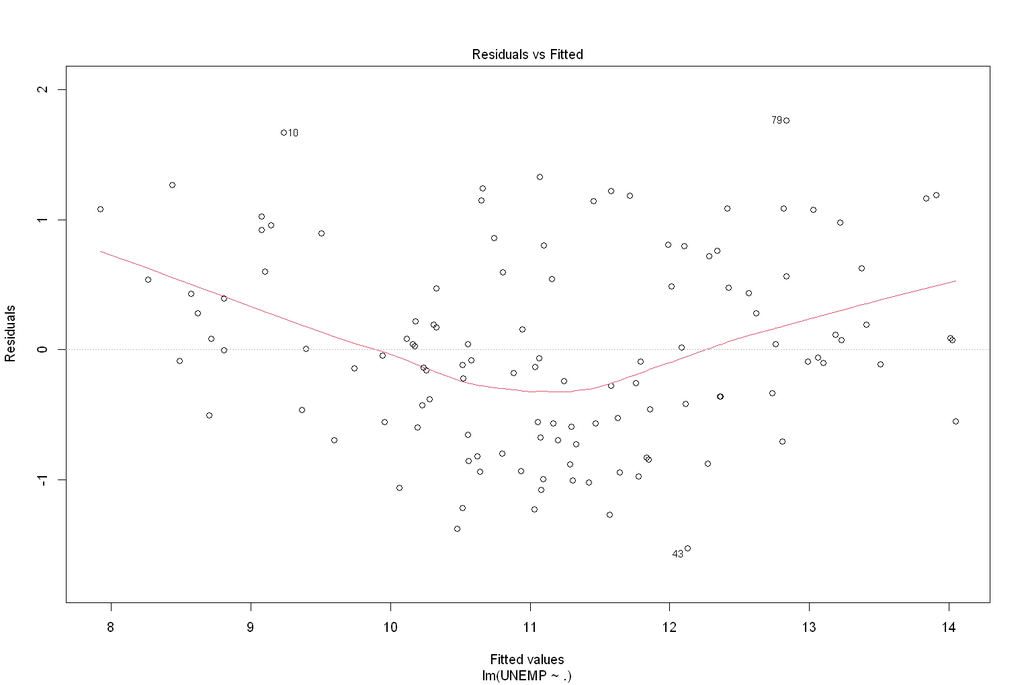

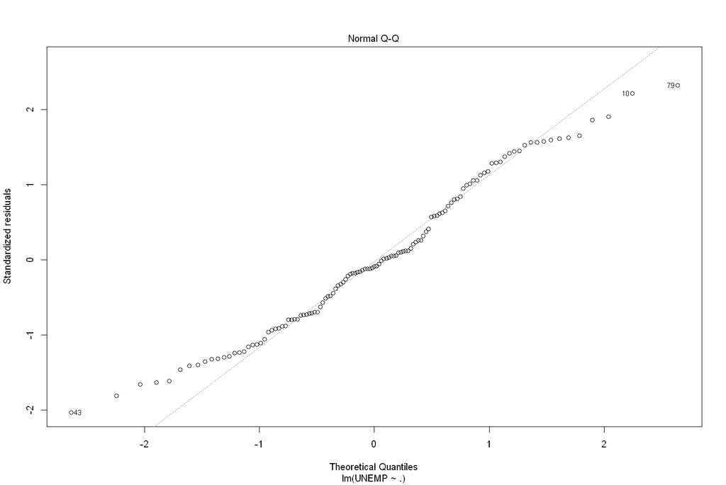

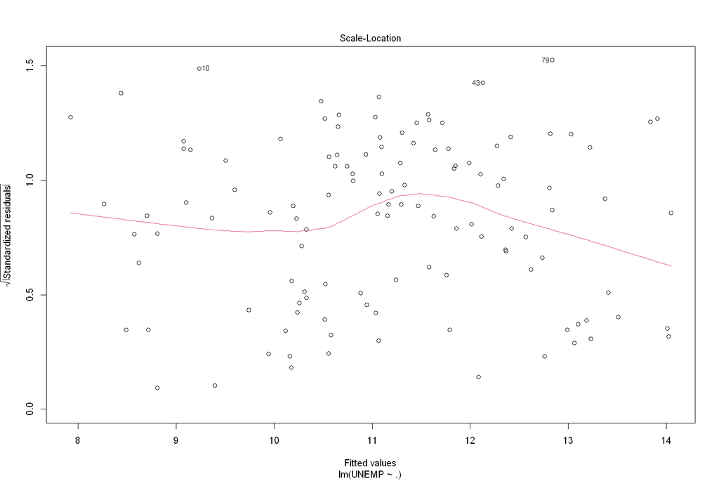

```
Call:
lm(formula = UNEMP ~ ., data = unemployement)

Residuals:
     Min       1Q   Median       3Q      Max
-1.52982 -0.56534 -0.06665  0.54301  1.76443

Coefficients:
                      Estimate Std. Error t value Pr(>|t|)
(Intercept)          5.320e+00  4.592e+00   1.158 0.249475
DATE                 1.727e-04  2.740e-04   0.630 0.530031
CBFON                2.049e-02  1.497e-02   1.369 0.174056
CPIG                 5.391e-03  2.929e-03   1.841 0.068687 .
CONTR               -2.998e-02  1.846e-02  -1.624 0.107586
GGSRCH               2.916e-02  8.436e-03   3.456 0.000809 ***
GDP                 -9.528e-10  4.785e-10  -1.991 0.049246 *
UNEMPlag6            3.105e-01  8.746e-02   3.550 0.000591 ***
COVID               -2.142e-07  2.462e-07  -0.870 0.386315
MPETR               -1.428e-02  4.688e-03  -3.045 0.002979 **
BIST100             -4.347e-04  2.852e-04  -1.524 0.130619
month_nameAugust     1.066e-02  4.074e-01   0.026 0.979169
month_nameDecember   8.364e-01  3.870e-01   2.161 0.033107 *
month_nameFebruary   1.060e+00  3.873e-01   2.738 0.007334 **
month_nameJanuary    1.184e+00  3.787e-01   3.128 0.002312 **
month_nameJuly       1.574e-01  4.231e-01   0.372 0.710654
month_nameJune      -3.880e-01  3.915e-01  -0.991 0.324178
month_nameMarch      4.395e-01  3.752e-01   1.171 0.244253
month_nameMay       -3.197e-01  3.697e-01  -0.865 0.389225
month_nameNovember   3.736e-01  3.942e-01   0.948 0.345492
month_nameOctober    3.070e-01  4.004e-01   0.767 0.445046
month_nameSeptember  8.157e-02  4.054e-01   0.201 0.840971
---
Signif. codes:  0 '***' 0.001 '**' 0.01 '*' 0.05 '.' 0.1 ' ' 1

Residual standard error: 0.816 on 99 degrees of freedom
Multiple R-squared:  0.7876,	Adjusted R-squared:  0.7426
F-statistic: 17.48 on 21 and 99 DF,  p-value: < 2.2e-16
```

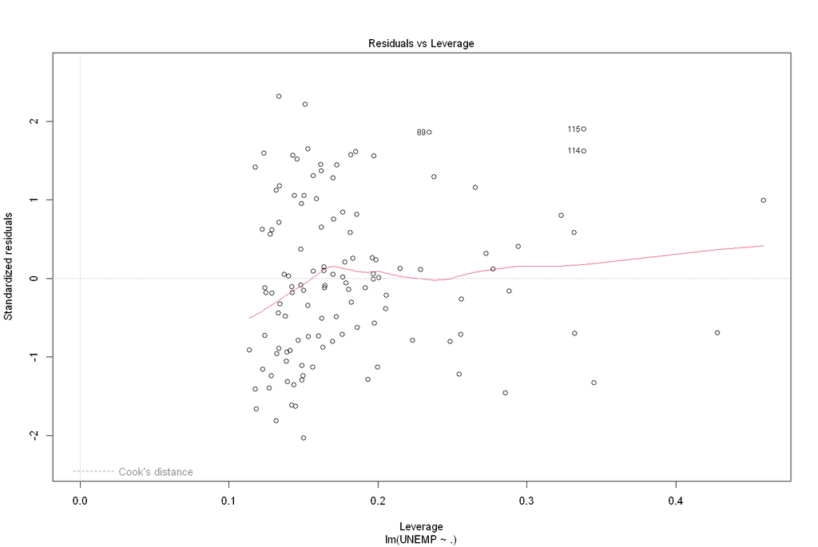

```r
sq_unemployement=copy(unemployement)
sq_unemployement$sq_UNEMP <- (unemployement$UNEMP)^2
sq_fit = lm(UNEMP~.,data=unemployement)
plot(sq_fit)
summary(sq_fit)
```

# We'll try one more model that has a combination of different nonlinear variables too.

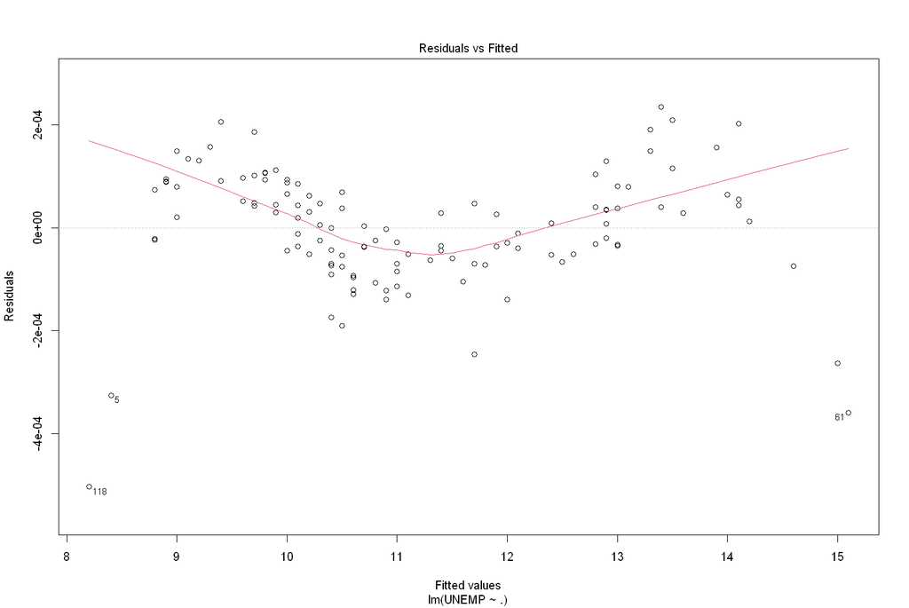

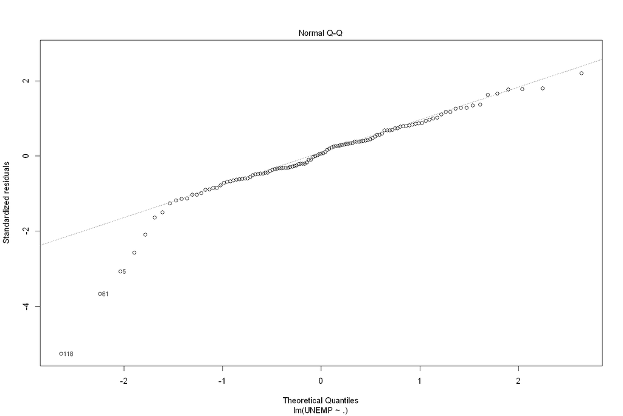

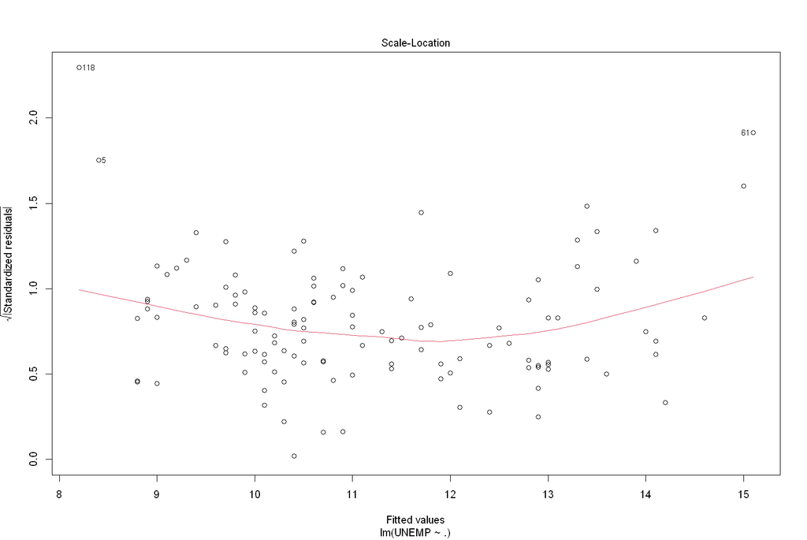

```
Call:
lm(formula = UNEMP ~ ., data = nlin_combined_unemployement)

Residuals:
       Min         1Q     Median         3Q        Max
-5.033e-04 -5.388e-05  7.230e-06  7.890e-05  2.350e-04

Coefficients:
                      Estimate Std. Error   t value Pr(>|t|)
(Intercept)         -6.108e+00  2.323e-03 -2630.068  < 2e-16 ***
DATE                -6.325e-08  4.456e-08    -1.420 0.158982
CBFON               -3.101e-06  2.395e-06    -1.294 0.198615
CPIG                -7.401e-08  4.715e-07    -0.157 0.875597
CONTR                8.668e-07  2.935e-06     0.295 0.768375
GGSRCH               1.094e-06  1.427e-06     0.767 0.444918
GDP                  6.529e-14  7.783e-14     0.839 0.403624
UNEMPlag6            5.608e-05  1.584e-05     3.541 0.000618 ***
COVID               -7.826e-11  3.914e-11    -2.000 0.048378 *
MPETR                8.121e-07  7.908e-07     1.027 0.307046
BIST100             -4.314e-09  4.582e-08    -0.094 0.925174
month_nameAugust    -1.497e-04  6.733e-05    -2.223 0.028586 *
month_nameDecember  -3.099e-05  6.282e-05    -0.493 0.622846
month_nameFebruary  -1.516e-04  6.413e-05    -2.364 0.020109 *
month_nameJanuary   -1.317e-04  6.401e-05    -2.058 0.042333 *
month_nameJuly      -1.903e-04  7.051e-05    -2.698 0.008234 **
month_nameJune      -4.521e-05  6.213e-05    -0.728 0.468613
month_nameMarch     -3.320e-05  5.976e-05    -0.556 0.579783
month_nameMay       -1.922e-05  5.918e-05    -0.325 0.746138
month_nameNovember  -4.077e-05  6.273e-05    -0.650 0.517313
month_nameOctober   -1.630e-04  6.442e-05    -2.530 0.013040 *
month_nameSeptember -1.266e-04  6.597e-05    -1.918 0.058040 .
sq_UNEMP             7.327e-03  2.915e-05   251.347  < 2e-16 ***
sqr_UNEMP            8.950e+00  1.807e-02   495.269  < 2e-16 ***
log_UNEMP           -5.614e+00  2.284e-02  -245.813  < 2e-16 ***
---
Signif. codes:  0 '***' 0.001 '**' 0.01 '*' 0.05 '.' 0.1 ' ' 1

Residual standard error: 0.0001273 on 96 degrees of freedom
Multiple R-squared:      1,	Adjusted R-squared:      1
F-statistic: 7.977e+08 on 24 and 96 DF,  p-value: < 2.2e-16
```

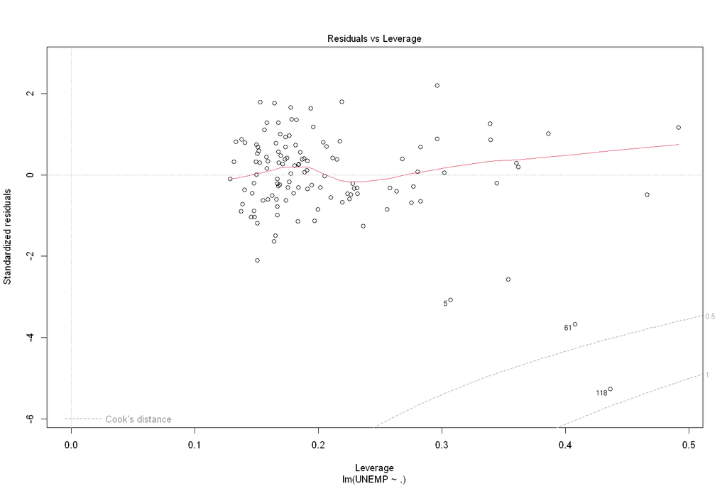

```r
nlin_combined_unemployement <- copy(unemployement)
nlin_combined_unemployement$sq_UNEMP <- (unemployement$UNEMP)^2
nlin_combined_unemployement$sqr_UNEMP <- sqrt(unemployement$UNEMP)
nlin_combined_unemployement$log_UNEMP <- log(unemployement$UNEMP)
nlin_combined_fit = lm(UNEMP~.,data=nlin_combined_unemployement)
plot(nlin_combined_fit)
summary(nlin_combined_fit)
```

# We're most likely overfitting in the combined model, but we'll keep it since we don't try to do any forecasting.

# NBesides the combined model, none of the transformations helped with the residuals well. However, since we have good R-squared results and p-values on all models, we can jump to checking which models is the best.

# Let's implement some performence measure tests.

```r
model_list <- list(
  sq_fit = sq_unemployement,
  log_fit = log_unemployement,
  sqr_fit = sqr_unemployement,
  l_fit2 = unemployement,
  nlin_combined_fit = nlin_combined_unemployement
)

perf_result <- data.table(Model = character(), mse = numeric(), mae = numeric(), mape = numeric(), wmape = numeric())

for (model_name in names(model_list)) {
  model <- lm(UNEMP ~ ., data = model_list[[model_name]])

  predicted_values <- predict(model)

  mse <- mean((predicted_values - model_list[[model_name]]$UNEMP)^2)
  mae <- mean(abs(predicted_values - model_list[[model_name]]$UNEMP))
  mape <- mean(abs(predicted_values - model_list[[model_name]]$UNEMP) / model_list[[model_name]]$UNEMP)
  wmape <- sum(abs(predicted_values - model_list[[model_name]]$UNEMP)) / sum(model_list[[model_name]]$UNEMP)

  perf_result <- rbind(perf_result, data.table(Model = model_name, mse = mse, mae = mae, mape = mape, wmape = wmape))
}

perf_result <- perf_result[order(wmape)]
print(perf_result)
```

```
               Model          mse          mae         mape        wmape
              <char>        <num>        <num>        <num>        <num>
1: nlin_combined_fit 1.286321e-08 8.494204e-05 7.840578e-06 7.609941e-06
2:           sqr_fit 2.001036e-03 3.234480e-02 2.956891e-03 2.897764e-03
3:            sq_fit 7.275581e-03 6.196673e-02 5.656274e-03 5.551588e-03
4:           log_fit 8.189228e-03 6.510363e-02 5.953509e-03 5.832622e-03
5:            l_fit2 5.447799e-01 6.031983e-01 5.478464e-02 5.404043e-02
```

# It seems the model combined model performs the best but we'll disregard it since we suspect of overfitting

# After that, the model with the additional square root variable performs the best on all tests.

# Looking at its residuals, it probably has some undercover properties that need to be analysed further but we'll keep it anyway.

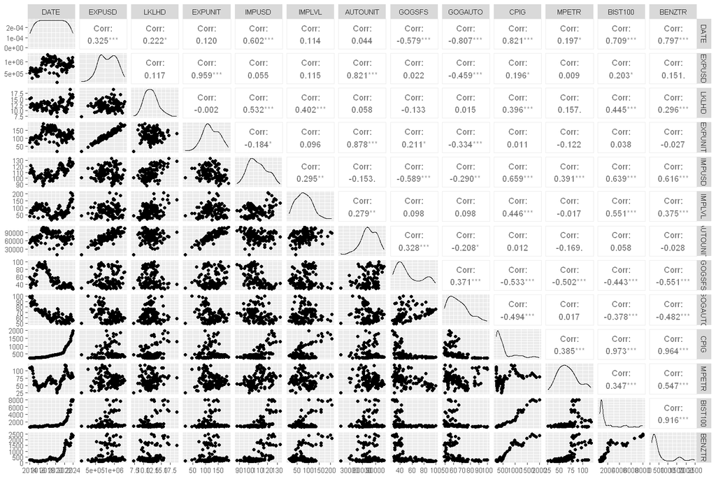

```
Call:
lm(formula = BENZTR ~ ., data = automobile)

Coefficients:
(Intercept)         DATE       EXPUSD        LKLHD      EXPUNIT       IMPUSD
 -3.017e+03    1.424e-01   -1.395e-03   -1.939e+01    8.007e+00    6.055e-02
     IMPLVL     AUTOUNIT       GOGSFS      GOGAUTO         CPIG        MPETR
  8.440e-01    6.763e-04    2.132e+00   -1.456e+00    1.364e+00    9.518e+00
    BIST100
 -2.699e-02
```

```
Call:
lm(formula = BENZTR ~ ., data = automobile)

Residuals:
     Min       1Q   Median       3Q      Max
-140.005  -46.699   -3.526   35.562  207.019

Coefficients:
              Estimate Std. Error t value Pr(>|t|)
(Intercept) -3.017e+03  5.442e+02  -5.544 2.12e-07 ***
DATE         1.424e-01  2.754e-02   5.171 1.08e-06 ***
EXPUSD      -1.395e-03  2.388e-04  -5.841 5.55e-08 ***
LKLHD       -1.939e+01  4.414e+00  -4.392 2.63e-05 ***
EXPUNIT      8.007e+00  1.755e+00   4.562 1.34e-05 ***
IMPUSD       6.055e-02  1.476e+00   0.041  0.96734
IMPLVL       8.440e-01  2.763e-01   3.055  0.00284 **
AUTOUNIT     6.763e-04  8.786e-04   0.770  0.44311
GOGSFS       2.132e+00  4.897e-01   4.354 3.05e-05 ***
GOGAUTO     -1.456e+00  1.170e+00  -1.244  0.21613
CPIG         1.364e+00  1.508e-01   9.043 6.95e-15 ***
MPETR        9.518e+00  4.879e-01  19.510  < 2e-16 ***
BIST100     -2.699e-02  2.655e-02  -1.016  0.31169
---
Signif. codes:  0 '***' 0.001 '**' 0.01 '*' 0.05 '.' 0.1 ' ' 1

Residual standard error: 72.2 on 108 degrees of freedom
Multiple R-squared:  0.9892,	Adjusted R-squared:  0.988
F-statistic: 821.4 on 12 and 108 DF,  p-value: < 2.2e-16
```

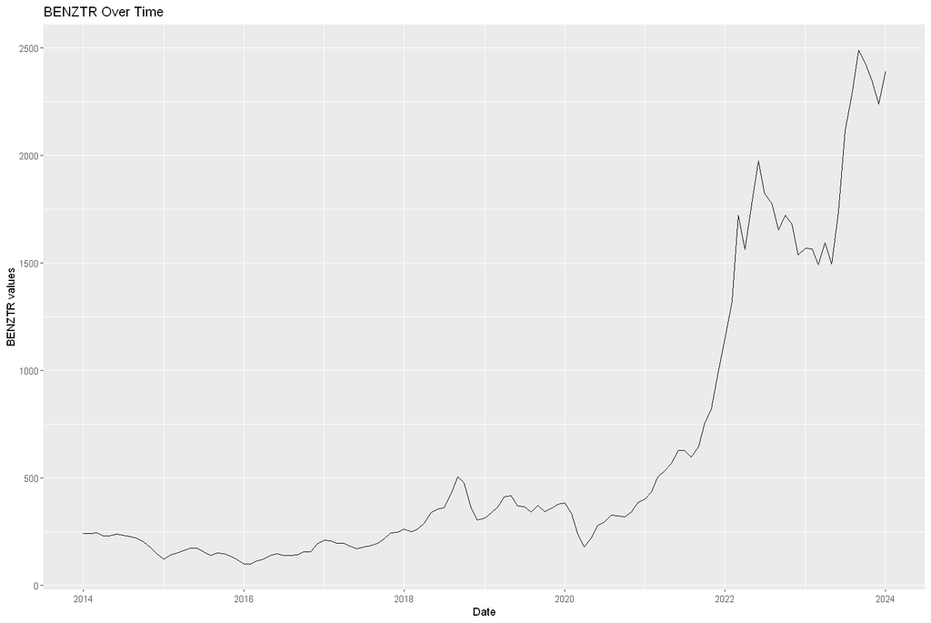

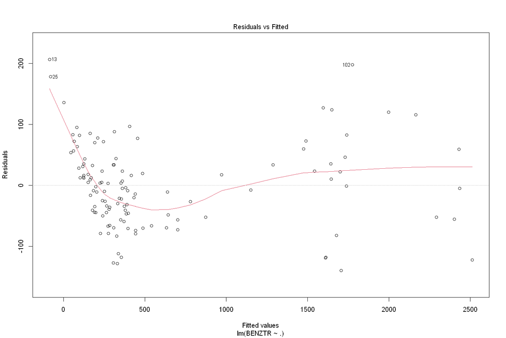

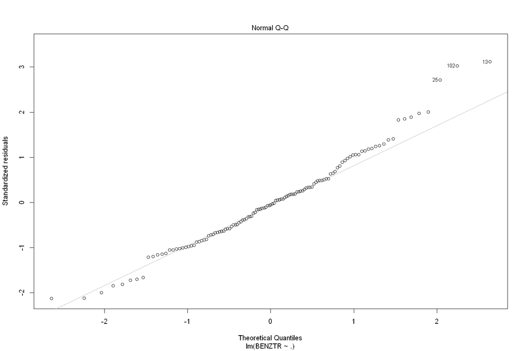

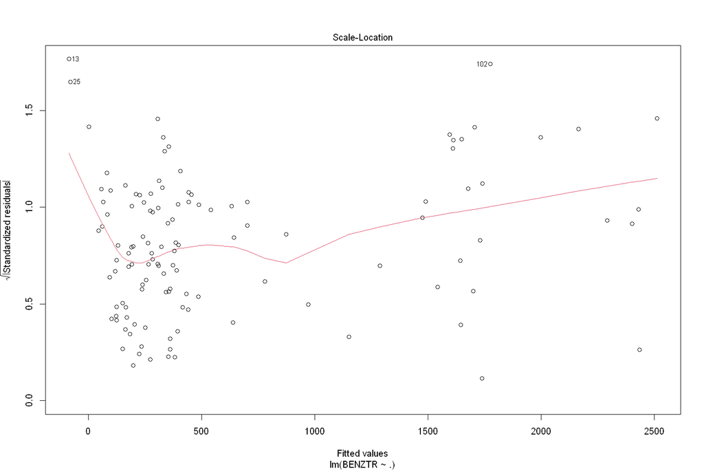

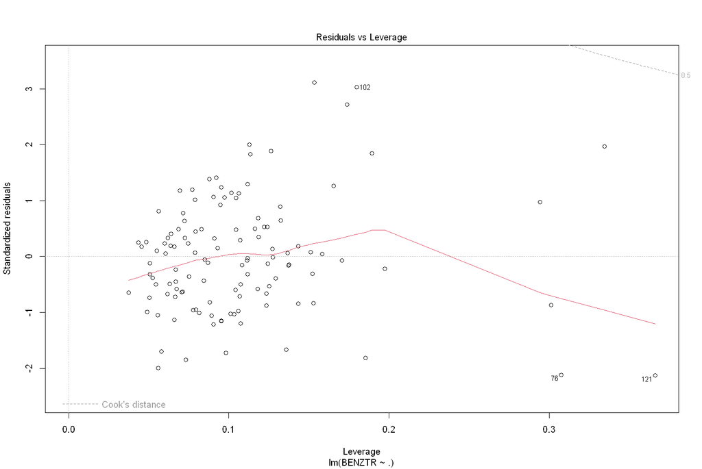

```r
automobile=read.xlsx(data_path,sheet='data_AUTO') #Reading the data
automobile$DATE <- as.Date(automobile$DATE, format = "%Y-%m-%d")
ggpairs(automobile)
ggplot(automobile, aes(x = DATE, y = BENZTR)) +  #exchange rate over time plot
  geom_line() +
  labs(x = "Date", y = "BENZTR values", title = "BENZTR Over Time")
l_fit3 = lm(BENZTR~.,data=automobile)
l_fit3
summary(l_fit3)
plot(l_fit3)
```

# There seems to be multicollinearity between multiple independent variables. However, it shouldn't be a problem in neither model-makin nor forecasting.

# We'll disregard multicollinearity since we're also not interested in creating a simulation.

# Also, looking at BENZTR over time, a logarithmic transformation seems necessary:

```
Call:
lm(formula = log_BENZTR ~ ., data = log_automobile)

Coefficients:
(Intercept)         DATE       EXPUSD        LKLHD      EXPUNIT       IMPUSD
 -4.945e+00    5.486e-04   -7.366e-07    6.794e-03    5.854e-03   -3.213e-03
     IMPLVL     AUTOUNIT       GOGSFS      GOGAUTO         CPIG        MPETR
  2.133e-04   -1.062e-06   -1.190e-03    3.274e-04    1.112e-04    1.602e-02
    BIST100       BENZTR
  4.168e-05    1.939e-04
```

```
Call:
lm(formula = log_BENZTR ~ ., data = log_automobile)

Residuals:
     Min       1Q   Median       3Q      Max
-0.19995 -0.04304 -0.00132  0.04379  0.25184

Coefficients:
              Estimate Std. Error t value Pr(>|t|)
(Intercept) -4.945e+00  5.996e-01  -8.247 4.49e-13 ***
DATE         5.486e-04  2.990e-05  18.350  < 2e-16 ***
EXPUSD      -7.366e-07  2.662e-07  -2.767  0.00667 **
LKLHD        6.794e-03  4.658e-03   1.458  0.14763
EXPUNIT      5.854e-03  1.863e-03   3.142  0.00217 **
IMPUSD      -3.213e-03  1.434e-03  -2.240  0.02714 *
IMPLVL       2.133e-04  2.799e-04   0.762  0.44772
AUTOUNIT    -1.061e-06  8.563e-07  -1.240  0.21780
GOGSFS      -1.190e-03  5.160e-04  -2.306  0.02303 *
GOGAUTO      3.274e-04  1.145e-03   0.286  0.77551
CPIG         1.112e-04  1.943e-04   0.572  0.56848
MPETR        1.602e-02  1.009e-03  15.886  < 2e-16 ***
BIST100      4.168e-05  2.593e-05   1.607  0.11090
BENZTR       1.939e-04  9.353e-05   2.073  0.04054 *
---
Signif. codes:  0 '***' 0.001 '**' 0.01 '*' 0.05 '.' 0.1 ' ' 1

Residual standard error: 0.07018 on 107 degrees of freedom
Multiple R-squared:  0.9947,	Adjusted R-squared:  0.9941
F-statistic:  1555 on 13 and 107 DF,  p-value: < 2.2e-16
```

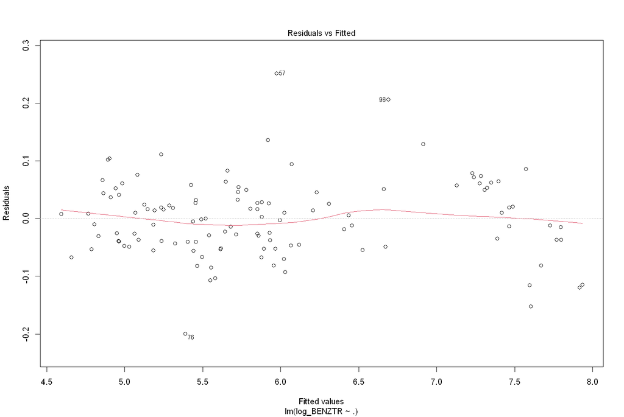

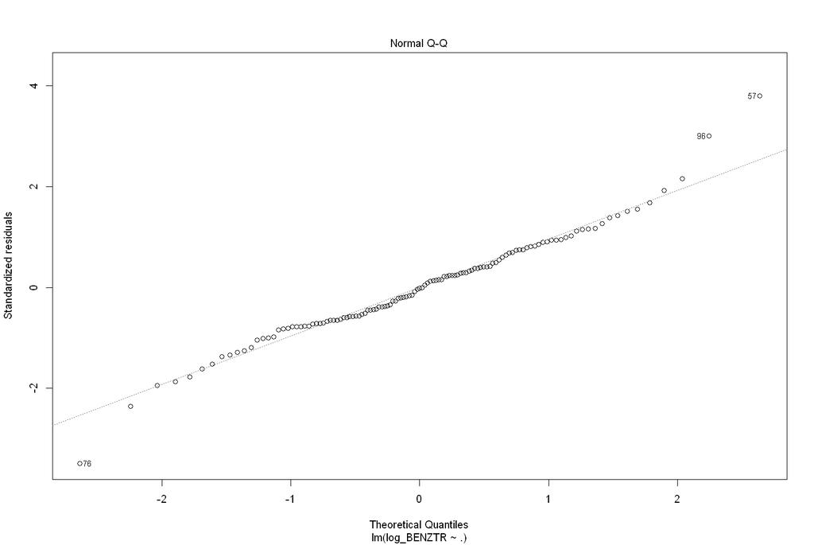

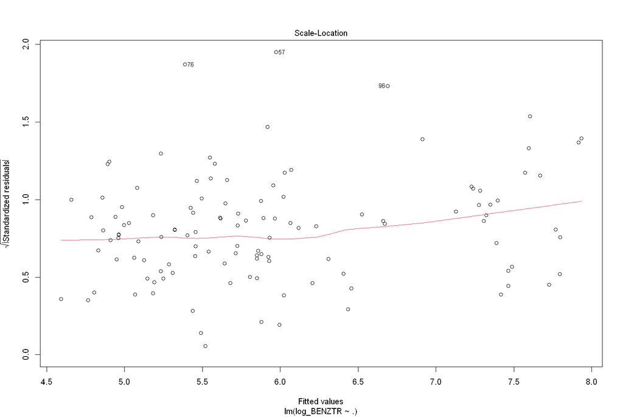

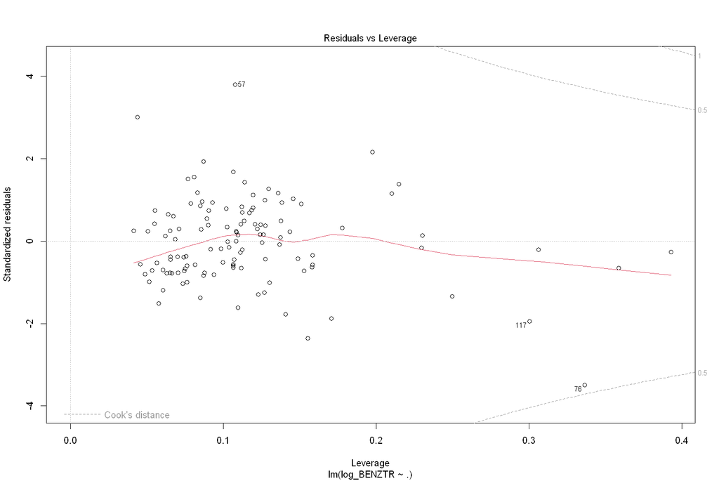

```r
log_automobile <- copy(automobile)
log_automobile$log_BENZTR <- log(automobile$BENZTR)
log_l_fit3 = lm(log_BENZTR~.,data=log_automobile)
log_l_fit3
summary(log_l_fit3)
plot(log_l_fit3)
```

# Residuals seems great but we also need to check ACF.

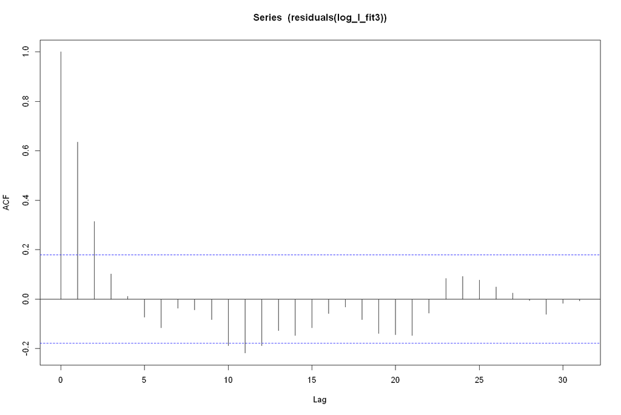

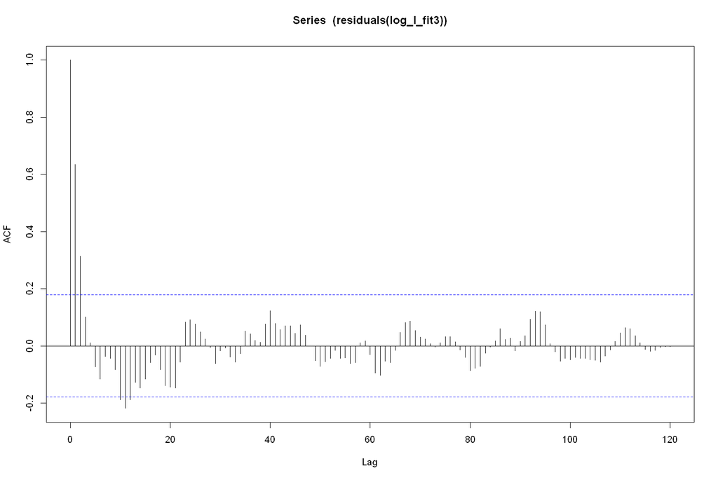

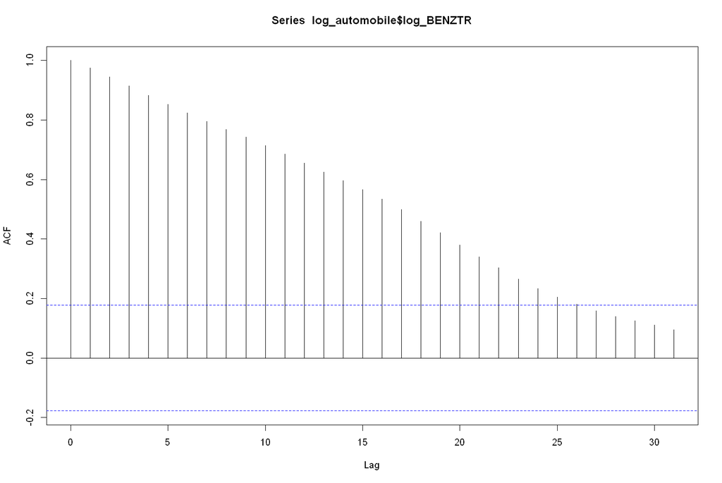

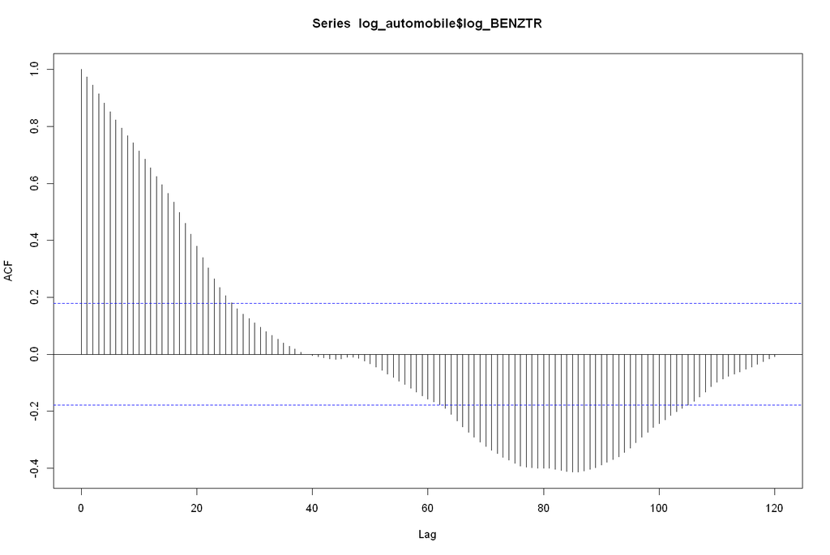

```r
acf((residuals(log_l_fit3)), lag.max = 31)
acf((residuals(log_l_fit3)), lag.max = 360)
acf(log_automobile$log_BENZTR, lag.max = 31)
acf(log_automobile$log_BENZTR, lag.max = 360)
```

# We can add a month categorical variable since there seems to be *significant* autocorrelation at lag 11-12.

```r
log_automobile$month_name <- month.name[month(log_automobile$DATE)] #Adding categorical month variables for seasonality
tail(exchange_rate)
```

A data.frame: 6 × 10

|  | DATE <date> | EXCH <dbl> | MEVTR <dbl> | REZV <dbl> | M3ARZ <dbl> | PAYTP <dbl> | CPIG <dbl> | CBBS <dbl> | BIST100 <dbl> | month_name <chr> |
| --- | --- | --- | --- | --- | --- | --- | --- | --- | --- | --- |
| 116 | 2023-08-01 | 26.99913 | 26.88 | 116647 | 12343401954 | 4340.17 | 1614.31 | 5186410031 | 7563.415 | August |
| 117 | 2023-09-01 | 26.98945 | 31.75 | 122196 | 12666105927 | 1190.97 | 1691.04 | 5538263802 | 8024.245 | September |
| 118 | 2023-10-01 | 27.84611 | 35.64 | 126185 | 13093467551 | 1055.18 | 1749.11 | 5778088947 | 7973.575 | October |
| 119 | 2023-11-01 | 28.63708 | 40.59 | 136680 | 13416124412 | 1402.29 | 1806.50 | 6278521190 | 7723.220 | November |
| 120 | 2023-12-01 | 29.07486 | 44.34 | 140884 | 14018354253 | 2768.09 | 1859.38 | 6520597030 | 7661.690 | December |
| 121 | 2024-01-01 | 30.05375 | 45.53 | 133858 | 14175495549 | 1454.27 | 1984.02 | 6506712407 | 7982.170 | January |

# Let's do the tests again

```
Call:
lm(formula = log_BENZTR ~ ., data = log_automobile)

Coefficients:
        (Intercept)                 DATE               EXPUSD
         -5.112e+00            5.547e-04           -8.606e-07
              LKLHD              EXPUNIT               IMPUSD
          7.907e-03            6.748e-03           -3.402e-03
             IMPLVL             AUTOUNIT               GOGSFS
          6.974e-04           -1.190e-06           -1.226e-03
            GOGAUTO                 CPIG                MPETR
         -4.574e-04            2.213e-04            1.684e-02
            BIST100               BENZTR     month_nameAugust
          2.148e-05            1.447e-04            5.336e-02
 month_nameDecember   month_nameFebruary    month_nameJanuary
          5.785e-02            3.329e-02            8.275e-02
     month_nameJuly       month_nameJune      month_nameMarch
          2.955e-02            9.025e-03           -2.204e-03
      month_nameMay   month_nameNovember    month_nameOctober
          1.104e-02            3.069e-02            1.780e-02
month_nameSeptember
          5.580e-02
```

```
Call:
lm(formula = log_BENZTR ~ ., data = log_automobile)

Residuals:
     Min       1Q   Median       3Q      Max
-0.15774 -0.03947  0.00061  0.04206  0.24119

Coefficients:
                      Estimate Std. Error t value Pr(>|t|)
(Intercept)         -5.112e+00  6.854e-01  -7.458 3.92e-11 ***
DATE                 5.547e-04  3.423e-05  16.206  < 2e-16 ***
EXPUSD              -8.606e-07  2.905e-07  -2.962  0.00385 **
LKLHD                7.907e-03  5.053e-03   1.565  0.12094
EXPUNIT              6.748e-03  2.053e-03   3.287  0.00142 **
IMPUSD              -3.402e-03  1.523e-03  -2.234  0.02779 *
IMPLVL               6.974e-04  3.688e-04   1.891  0.06163 .
AUTOUNIT            -1.190e-06  1.026e-06  -1.160  0.24897
GOGSFS              -1.226e-03  5.359e-04  -2.288  0.02435 *
GOGAUTO             -4.574e-04  1.366e-03  -0.335  0.73837
CPIG                 2.213e-04  2.034e-04   1.088  0.27923
MPETR                1.684e-02  1.090e-03  15.456  < 2e-16 ***
BIST100              2.148e-05  2.720e-05   0.790  0.43166
BENZTR               1.447e-04  9.800e-05   1.477  0.14298
month_nameAugust     5.336e-02  3.683e-02   1.449  0.15063
month_nameDecember   5.785e-02  3.402e-02   1.700  0.09227 .
month_nameFebruary   3.329e-02  3.250e-02   1.024  0.30824
month_nameJanuary    8.275e-02  3.563e-02   2.322  0.02233 *
month_nameJuly       2.955e-02  3.595e-02   0.822  0.41310
month_nameJune       9.025e-03  3.367e-02   0.268  0.78922
month_nameMarch     -2.204e-03  3.267e-02  -0.067  0.94635
month_nameMay        1.104e-02  3.197e-02   0.345  0.73050
month_nameNovember   3.069e-02  3.358e-02   0.914  0.36300
month_nameOctober    1.780e-02  3.377e-02   0.527  0.59944
month_nameSeptember  5.580e-02  3.502e-02   1.593  0.11434
---
Signif. codes:  0 '***' 0.001 '**' 0.01 '*' 0.05 '.' 0.1 ' ' 1

Residual standard error: 0.07008 on 96 degrees of freedom
Multiple R-squared:  0.9953,	Adjusted R-squared:  0.9941
F-statistic:   845 on 24 and 96 DF,  p-value: < 2.2e-16
```

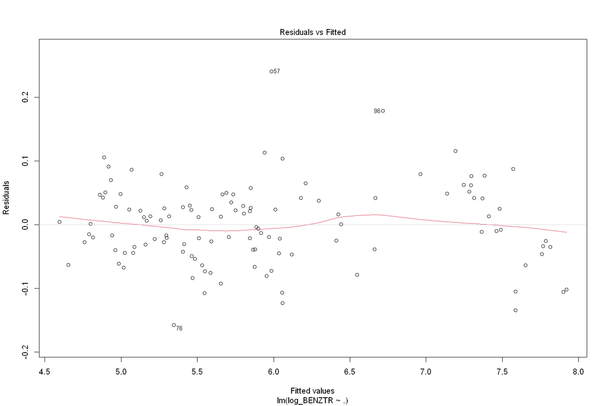

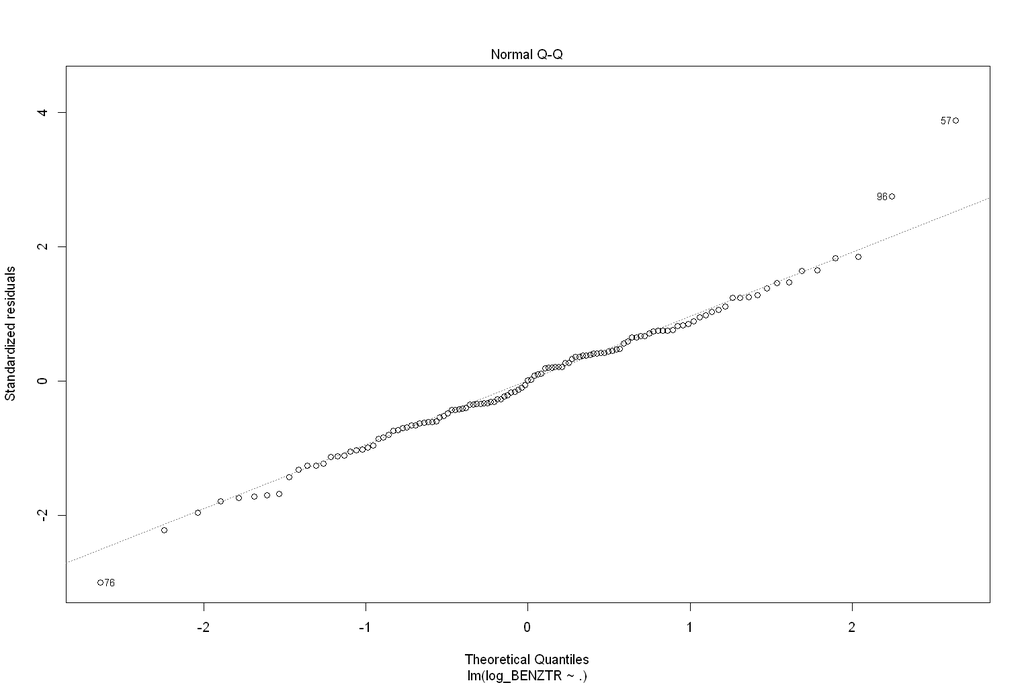

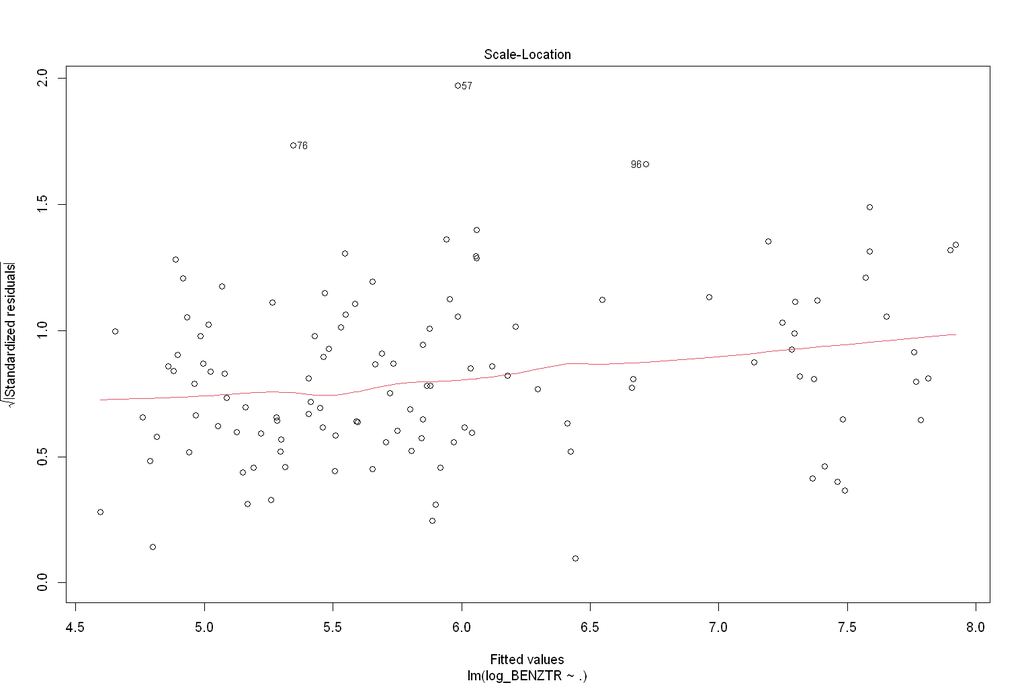

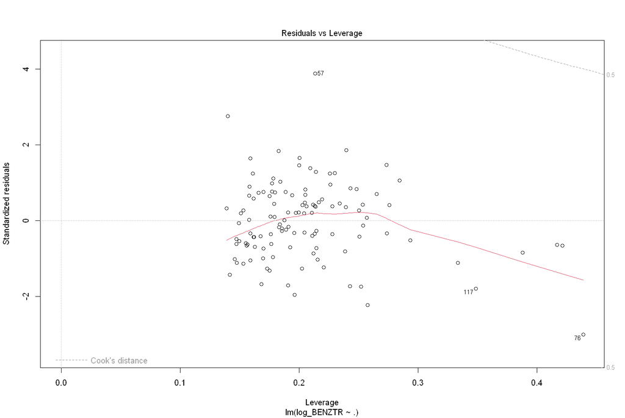

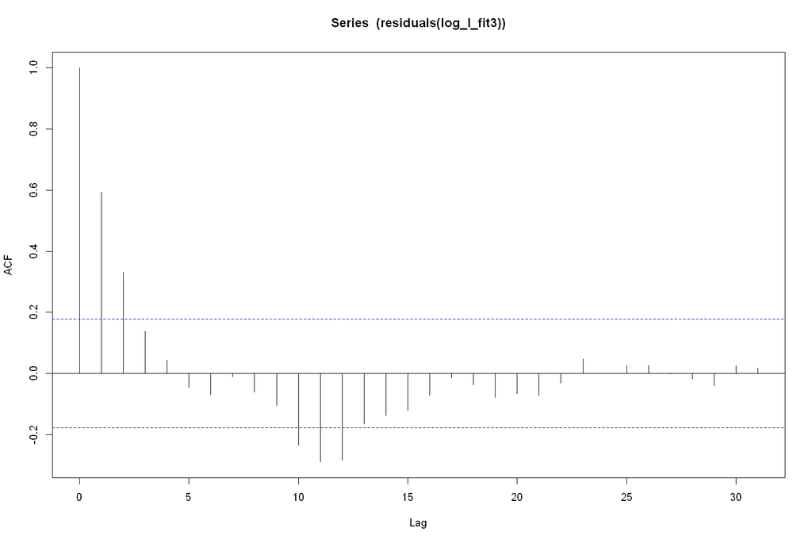

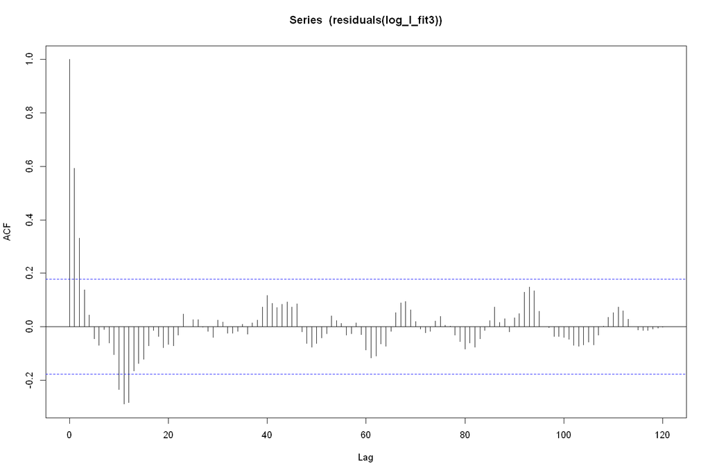

```r
log_l_fit3 = lm(log_BENZTR~.,data=log_automobile)
log_l_fit3
summary(log_l_fit3)
plot(log_l_fit3)
acf((residuals(log_l_fit3)), lag.max = 31)
acf((residuals(log_l_fit3)), lag.max = 360)
```

# The result didn't change much but our model was accurate already so it's okay to keep the categorical month variables.